# Coronavirus Case Study

Solomon Heisey

6/10/2020

The novel Coronavirus has effected everyone in some shape or form. One of the largest problems of this virus is the minute amount of information we currently know about it. This statistical analysis I have prepared aims to shed some light on the current situation and expose trends that are often hidden to the naked eye.

For this project, I am using the Johns Hopkins University Center for Systems Science and Engineering (JHU CCSE) Coronavirus repository. Below is a summary of the dataset.

This coronavirus dataset has the following fields:

- date - The date of the summary
- province - The province or state, when applicable
- country - The country or region name
- lat - Latitude point
- long - Longitude point
- type - the type of case (i.e., confirmed, death)
- cases - the number of daily cases (corresponding to the case type)

```
##       date              province           country               lat
##  Min.   :2020-01-22   Length:107545      Length:107545      Min.   :-51.796
##  1st Qu.:2020-02-25   Class :character   Class :character   1st Qu.:  6.611
##  Median :2020-03-30   Mode  :character   Mode  :character   Median : 22.300
##  Mean   :2020-03-30                                         Mean   : 20.714
##  3rd Qu.:2020-05-03                                         3rd Qu.: 40.143
##  Max.   :2020-06-06                                         Max.   : 71.707
##       long             type               cases
##  Min.   :-135.00   Length:107545      Min.   :-10034.00
##  1st Qu.: -14.45   Class :character   1st Qu.:     0.00
##  Median :  21.76   Mode  :character   Median :     0.00
##  Mean   :  24.35                      Mean   :    96.49
##  3rd Qu.:  81.00                      3rd Qu.:     2.00
##  Max.   : 178.06                      Max.   : 51717.00
```

Shown below is a simple bar graph depicting the total number of confirmed cases on a per-country basis. The countries are sorted in descending order and listed below the graph is the raw data.

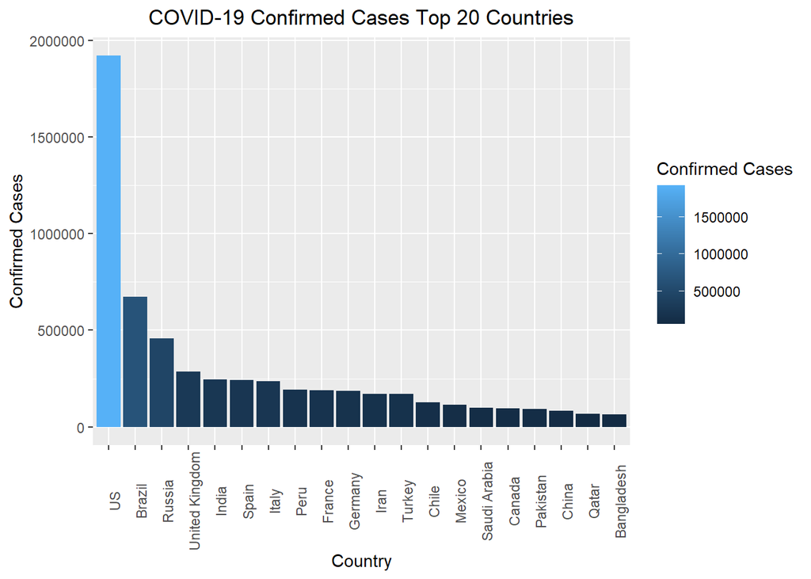

```
## # A tibble: 20 x 2
##    country        total_cases
##    <chr>                <int>
##  1 US                 1920061
##  2 Brazil              672846
##  3 Russia              458102
##  4 United Kingdom      286294
##  5 India               246622
##  6 Spain               241310
##  7 Italy               234801
##  8 Peru                191758
##  9 France              190759
## 10 Germany             185450
## 11 Iran                169425
## 12 Turkey              169218
## 13 Chile               127745
## 14 Mexico              113619
## 15 Saudi Arabia         98869
## 16 Canada               96475
## 17 Pakistan             93983
## 18 China                84186
## 19 Qatar                67195
## 20 Bangladesh           63026
```

Show below is a tree map depicting the total number of recovered cases on a per-country basis. The countries are sorted in descending order and the percentage represents the number of people who have recovered from the virus after previously being diagnosed.

[interactive chart not shown]

Show below is a line graph depicting the total number of recovered, active, and death cases on a worldwide scale. Since number of cases is the sum of all recovered, active, and dead cases the three attributes can be stacked for better visualization.

[interactive chart not shown]

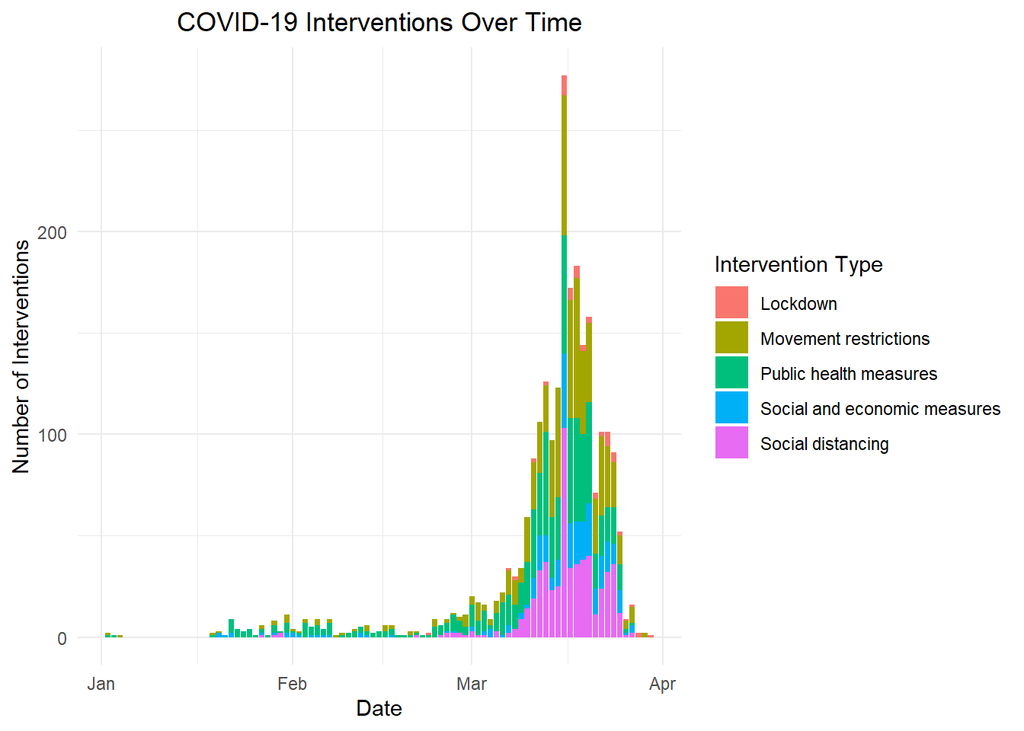